# FID - Predicción del Mundial 2022

Equipo8

## Introducción al proyecto

En este proyecto queremos abordar la predicción de partidos del mundial de fútbol de Qatar 2022. Para ello, emplearemos distintas técnicas que hemos visto en clase para realizar esta predicción.

Usaremos el siguiente dataset de Kaggle, https://www.kaggle.com/datasets/brenda89/fifa-world-cup-2022, donde podemos encontrar los resultados exactos de partidos de futbol de selecciones desde 1993 hasta 2022. El proyecto constará de los dos siguientes algoritmos:

1. Aprendizaje supervisado: predicción del resultado de partidos del mundial de Qatar 2022.
2. Aprendizaje no supervisado: Agrupación de equipos en base a sus puntuaciones de defensa, centro, ataque y portería.

Primero, empezaremos instalando y cargando todas las librerías que necesitaremos para el proyecto, y leyendo el dataset que hemos mencionado anteriormente.

**Carga de librerías**

```r
library(caret)
library(tidyverse)
library(readr)
library(randomForest)
library(dplyr)
library(DescTools)
library(corrplot)
library(ggplot2)
library(ggrepel)
library(cluster)
library(factoextra)
library(gridExtra)
library(dendextend)
library(aricode)
```

## Análisis exploratorio de los datos

```r
international_matches <- read_csv("datasets/international_matches.csv")
international_matches
```

| date | home_team | away_team | home_team_continent | away_team_continent | home_team_fifa_rank | away_team_fifa_rank | home_team_total_fifa_points | away_team_total_fifa_points | home_team_score | away_team_score | tournament | city | country | neutral_location | shoot_out | home_team_result | home_team_goalkeeper_score | away_team_goalkeeper_score | home_team_mean_defense_score | home_team_mean_offense_score | home_team_mean_midfield_score | away_team_mean_defense_score | away_team_mean_offense_score | away_team_mean_midfield_score |
| --- | --- | --- | --- | --- | --- | --- | --- | --- | --- | --- | --- | --- | --- | --- | --- | --- | --- | --- | --- | --- | --- | --- | --- | --- |
| 1993-08-08 | Bolivia | Uruguay | South America | South America | 59 | 22 | 0 | 0 | 3 | 1 | FIFA World Cup qualification | La Paz | Bolivia | FALSE | No | Win | NA | NA | NA | NA | NA | NA | NA | NA |
| 1993-08-08 | Brazil | Mexico | South America | North America | 8 | 14 | 0 | 0 | 1 | 1 | Friendly | Maceió | Brazil | FALSE | No | Draw | NA | NA | NA | NA | NA | NA | NA | NA |
| 1993-08-08 | Ecuador | Venezuela | South America | South America | 35 | 94 | 0 | 0 | 5 | 0 | FIFA World Cup qualification | Quito | Ecuador | FALSE | No | Win | NA | NA | NA | NA | NA | NA | NA | NA |
| 1993-08-08 | Guinea | Sierra Leone | Africa | Africa | 65 | 86 | 0 | 0 | 1 | 0 | Friendly | Conakry | Guinea | FALSE | No | Win | NA | NA | NA | NA | NA | NA | NA | NA |
| 1993-08-08 | Paraguay | Argentina | South America | South America | 67 | 5 | 0 | 0 | 1 | 3 | FIFA World Cup qualification | Asunción | Paraguay | FALSE | No | Lose | NA | NA | NA | NA | NA | NA | NA | NA |
| 1993-08-08 | Peru | Colombia | South America | South America | 70 | 19 | 0 | 0 | 0 | 1 | FIFA World Cup qualification | Lima | Peru | FALSE | No | Lose | NA | NA | NA | NA | NA | NA | NA | NA |
| 1993-08-08 | Zimbabwe | Eswatini | Africa | Africa | 50 | 102 | 0 | 0 | 2 | 0 | Friendly | Harare | Zimbabwe | FALSE | No | Win | NA | NA | NA | NA | NA | NA | NA | NA |
| 1993-08-09 | Guinea | Sierra Leone | Africa | Africa | 65 | 86 | 0 | 0 | 4 | 0 | Friendly | Conakry | Guinea | FALSE | No | Win | NA | NA | NA | NA | NA | NA | NA | NA |
| 1993-08-11 | Faroe Islands | Norway | Europe | Europe | 111 | 9 | 0 | 0 | 0 | 7 | Friendly | Toftir | Faroe Islands | FALSE | No | Lose | NA | NA | NA | NA | NA | NA | NA | NA |
| 1993-08-11 | Sweden | Switzerland | Europe | Europe | 4 | 3 | 0 | 0 | 1 | 2 | Friendly | Borås | Sweden | FALSE | No | Lose | NA | NA | NA | NA | NA | NA | NA | NA |

[output cut: 990 more lines]

En nuestro dataset tenemos 25 columnas con 23.921 filas, con información sobre partidos desde 1993 a 2022. Estos partidos contienen los equipos que lo jugaron, dónde lo jugaron, cuándo lo jugaron, qué resultado obtuvieron, el torneo del partido y información relativa sobre el rendimiento en portería, defensa, mediocentro y ataque de ambos equipos.

Primero debemos decidir si para nuestro caso de estudio necesitaremos todos los ejemplos o podemos deshacernos de algunos para agilizar la computación.

**Selección de los datos**

```r
supervised_international_matches <- international_matches[as.Date(international_matches$date) >= as.Date("2012-01-01"), ]

supervised_international_matches
```

| date | home_team | away_team | home_team_continent | away_team_continent | home_team_fifa_rank | away_team_fifa_rank | home_team_total_fifa_points | away_team_total_fifa_points | home_team_score | away_team_score | tournament | city | country | neutral_location | shoot_out | home_team_result | home_team_goalkeeper_score | away_team_goalkeeper_score | home_team_mean_defense_score | home_team_mean_offense_score | home_team_mean_midfield_score | away_team_mean_defense_score | away_team_mean_offense_score | away_team_mean_midfield_score |
| --- | --- | --- | --- | --- | --- | --- | --- | --- | --- | --- | --- | --- | --- | --- | --- | --- | --- | --- | --- | --- | --- | --- | --- | --- |
| 2012-01-06 | Equatorial Guinea | South Africa | Africa | Africa | 150 | 52 | 147 | 577 | 0 | 0 | Friendly | Bata | Equatorial Guinea | FALSE | No | Draw | NA | 76 | NA | 60.0 | NA | 69.8 | 72.0 | 75.2 |
| 2012-01-07 | Botswana | Zimbabwe | Africa | Africa | 95 | 98 | 371 | 354 | 0 | 0 | Friendly | Gaborone | Botswana | FALSE | No | Draw | NA | NA | NA | NA | NA | 64.2 | 69.0 | 62.8 |
| 2012-01-09 | Gabon | Burkina Faso | Africa | Africa | 77 | 62 | 445 | 517 | 0 | 0 | Friendly | Bitam | Gabon | FALSE | No | Draw | 67 | NA | NA | 74.3 | NA | NA | 72.3 | NA |
| 2012-01-09 | Tunisia | Sudan | Africa | Africa | 59 | 113 | 537 | 297 | 3 | 0 | Friendly | Sharjah | United Arab Emirates | TRUE | No | Win | 67 | NA | 75.0 | 72.3 | 71.8 | NA | NA | NA |
| 2012-01-11 | Nigeria | Angola | Africa | Africa | 43 | 83 | 627 | 411 | 0 | 0 | Friendly | Abuja | Nigeria | FALSE | No | Draw | 76 | 60 | 74.5 | 77.7 | 76.2 | 60.5 | 71.3 | NA |
| 2012-01-12 | Senegal | Sudan | Africa | Africa | 44 | 113 | 624 | 297 | 1 | 0 | Friendly | Dakar | Senegal | FALSE | No | Win | 67 | NA | 76.5 | 80.3 | 74.2 | NA | NA | NA |
| 2012-01-13 | Tunisia | Côte d'Ivoire | Africa | Africa | 59 | 16 | 537 | 911 | 0 | 2 | Friendly | Abu Dhabi | United Arab Emirates | TRUE | No | Lose | 67 | 72 | 75.0 | 72.3 | 71.8 | 75.5 | 83.7 | 79.2 |
| 2012-01-14 | Angola | Sierra Leone | Africa | Africa | 83 | 60 | 411 | 526 | 3 | 1 | Friendly | Cabinda | Angola | FALSE | No | Win | 60 | NA | 60.5 | 71.3 | NA | NA | 64.7 | 61.0 |
| 2012-01-14 | Zambia | Namibia | Africa | Africa | 79 | 121 | 439 | 264 | 0 | 0 | Friendly | Johannesburg | South Africa | TRUE | No | Draw | NA | NA | NA | NA | NA | NA | NA | NA |
| 2012-01-15 | Oman | Congo DR | Asia | Africa | 85 | 125 | 408 | 253 | 2 | 2 | Friendly | Muscat | Oman | FALSE | No | Draw | 77 | 63 | NA | NA | NA | 70.0 | 73.3 | 71.5 |

[output cut: 990 more lines]

**Balanceo de clases**

Comenzaremos estudiando el desbalanceo de clases. Como se puede ver a continuación, se tiene un 48% de ejemplos etiquetados como “Victoria”, un 29% “Derrota” y un 23% “Empate”, aproximadamente.

```r
prop.table(table(supervised_international_matches$home_team_result))
```

```
     Draw      Lose       Win
0.2253751 0.2891933 0.4854316
```

Las clases se encuentran desbalanceadas, aunque no de una forma muy significativa. Sin embargo, esto será un factor a tener en cuenta a la hora de seleccionar la métrica para evaluar y comparar los distintos modelos.

**Correlación de atributos**

Otro de los puntos a tener en cuenta previamente al entrenamiento del modelo es la correlación entre los atributos del conjunto de datos. Dado que la clase a predecir es una variable categórica (nominal), se ha utilizado el coeficiente V de Crammer para evaluar el grado de asociación entre los atributos. Cabe destacar que se han realizado dos evaluaciones, ya que que podemos distinguir entre dos tipos de partidos:

- **Amistosos:** En estos partidos existe un equipo local y un equipo visitante, pues se juegan en la ciudad del equipo local. Esto puede provocar que el resultado se vea afectado por factores externos (mayor cantidad de aficionados locales en el campo), al contrario que en partidos oficiales.
- **Oficiales:** Estos partidos se juegan en terreno neutral, por lo que no hay equipo local ni visitante, de manera que factores externos como la cantidad de aficionados o el terreno de juego no influyen de manera significativa en el resultado. Esta es la situación que se ajusta mejor a las necesidades del algoritmo que se pretende obtener, pues se quieren predecir los resultados de los partidos del mundial de 2022, que son todos de carácter oficial.

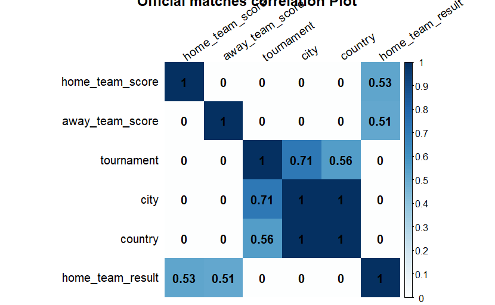

```r
# Get official and friendly matches
allMatches <- supervised_international_matches[,-c(1,2,3,4,5,6,7,8,9,15,16)][1:6]
officialMatches <- allMatches[allMatches$tournament != "Friendly",]
friendlyMatches <- allMatches[allMatches$tournament == "Friendly", -c(3)]

# Use CramerV as input for corrplot
mOfficial <- DescTools::PairApply(officialMatches, DescTools::CramerV)
mFriendly <- DescTools::PairApply(friendlyMatches, DescTools::CramerV)

# Display only strongly associated:
mOfficial[mOfficial < 0.5] <- 0
mFriendly[mFriendly < 0.5] <- 0

# Calculate correlation:
mOfficialCor <- scales::rescale(mOfficial, to=c(0,1))
mFriendlyCor <- scales::rescale(mFriendly, to=c(0,1))

# Plot
corrplot::corrplot(mOfficialCor, title = "Official matches correlation Plot", method="shade", tl.col="black", tl.srt=35, addCoef.col = 1, col.lim = c(0,1))
```

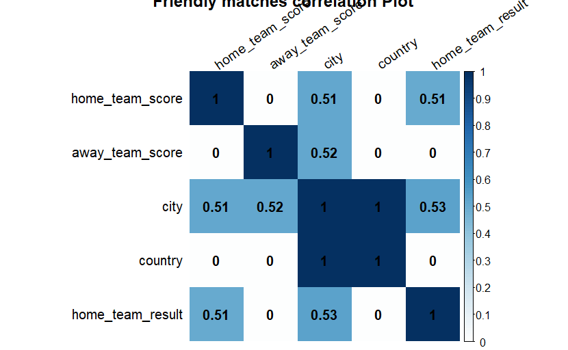

```r
corrplot::corrplot(mFriendlyCor, title = "Friendly matches correlation Plot", method="shade", tl.col="black", tl.srt=35, addCoef.col = 1, col.lim = c(0,1))
```

## Aprendizaje Supervisado: Predicción de resultados

Ahora que hemos analizado el dataset, vamos a realizar algunas técnicas de preprocesado para el modelo de aprendizaje supervisado.

**Corrección del balanceo de clases**

```r
# Use gsub() to replace all instances of "Draw" and "Lose" for "No Win"
supervised_international_matches$home_team_result <- gsub("Draw", "Lose", supervised_international_matches$home_team_result)

supervised_international_matches$home_team_result <- gsub("Lose", "NoWin", supervised_international_matches$home_team_result)

prop.table(table(supervised_international_matches$home_team_result))
```

```
    NoWin       Win
0.5145684 0.4854316
```

**Preselección de atributos**

Para el algoritmo predictivo de aprendizaje supervisado eliminaremos todas las columnas detrás de la 17. Estas columnas nos dan información sobre la puntuación general que obtuvo un equipo en defensa, centro y delantera, y no nos son relevantes ya que ganar por 1 gol es igual que ganar por 10, o hacer 10 paradas en un partido no importa si al final el equipo ha perdido. (Usaremos estos datos más adelante para el algoritmo no supervisado).

```r
colnames <- colnames(international_matches)

# Eliminamos las ultimas variables de información de equipo, defensa, centro y ataque
supervised_international_matches <- supervised_international_matches[, colnames[1:17]]

#Eliminamos la fecha de los partidos y la puntuación de los partidos, ya que nuestro algoritmo debe predecir Victoria/Derrota, no el resultado exacto
supervised_international_matches <- supervised_international_matches[, -c(1, 10, 11)]

supervised_international_matches
```

| home_team | away_team | home_team_continent | away_team_continent | home_team_fifa_rank | away_team_fifa_rank | home_team_total_fifa_points | away_team_total_fifa_points | tournament | city | country | neutral_location | shoot_out | home_team_result |
| --- | --- | --- | --- | --- | --- | --- | --- | --- | --- | --- | --- | --- | --- |
| Equatorial Guinea | South Africa | Africa | Africa | 150 | 52 | 147 | 577 | Friendly | Bata | Equatorial Guinea | FALSE | No | NoWin |
| Botswana | Zimbabwe | Africa | Africa | 95 | 98 | 371 | 354 | Friendly | Gaborone | Botswana | FALSE | No | NoWin |
| Gabon | Burkina Faso | Africa | Africa | 77 | 62 | 445 | 517 | Friendly | Bitam | Gabon | FALSE | No | NoWin |
| Tunisia | Sudan | Africa | Africa | 59 | 113 | 537 | 297 | Friendly | Sharjah | United Arab Emirates | TRUE | No | Win |
| Nigeria | Angola | Africa | Africa | 43 | 83 | 627 | 411 | Friendly | Abuja | Nigeria | FALSE | No | NoWin |
| Senegal | Sudan | Africa | Africa | 44 | 113 | 624 | 297 | Friendly | Dakar | Senegal | FALSE | No | Win |
| Tunisia | Côte d'Ivoire | Africa | Africa | 59 | 16 | 537 | 911 | Friendly | Abu Dhabi | United Arab Emirates | TRUE | No | NoWin |
| Angola | Sierra Leone | Africa | Africa | 83 | 60 | 411 | 526 | Friendly | Cabinda | Angola | FALSE | No | Win |
| Zambia | Namibia | Africa | Africa | 79 | 121 | 439 | 264 | Friendly | Johannesburg | South Africa | TRUE | No | NoWin |
| Oman | Congo DR | Asia | Africa | 85 | 125 | 408 | 253 | Friendly | Muscat | Oman | FALSE | No | NoWin |

[output cut: 990 more lines]

**Evaluación de los atributos - Random Forest**

Ahora, vamos a hacer un análisis de la importancia de las variables restantes del dataset. Usaremos un algoritmo de tipo Random Forest, entrenando primero el dataset con Cross Validation 3-Fold para evitar el Overfitting. Para ello, dividimos el dataset “supervised_international_matches” en 2 partes, un 70% del dataset lo usaremos para entrenar y el otro 30% para validar.

```r
# Create training and test set, based on 70/30 distribution.
supervised_partition <- createDataPartition(supervised_international_matches$home_team_result, p = 0.7, list = FALSE)

supervised_training_set <- supervised_international_matches[supervised_partition,]
supervised_test_set <- supervised_international_matches[-supervised_partition,]
```

Una vez creados las particiones, entrenamos el modelo con el método 3-fold CV:

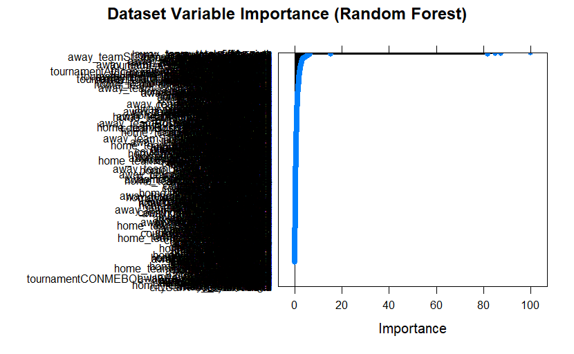

```r
set.seed(355)

## 3-fold CV
supervised_fit_control <- trainControl(
                           method = "repeatedcv",
                           number = 3,
                           repeats = 3)

supervised_random_forest <- train(home_team_result ~., data = supervised_training_set,
            method = "rf",
            trControl = supervised_fit_control)

supervised_var_importance <- varImp(supervised_random_forest)
plot(supervised_var_importance, main = "Dataset Variable Importance (Random Forest)")
```

```r
supervised_var_importance
```

```
rf variable importance

  only 20 most important variables shown (out of 718)
```

|  | Overall |
| --- | --- |
| away_team_total_fifa_points | 100.000000 |
| away_team_fifa_rank | 87.354202 |
| home_team_fifa_rank | 84.950089 |
| home_team_total_fifa_points | 81.809172 |
| neutral_locationTRUE | 15.086518 |
| cityBafoussam | 6.355886 |
| tournamentFriendly | 6.016863 |
| cityDouala | 5.773927 |
| away_teamGuinea | 5.394598 |
| away_teamSt. Vincent and the Grenadines | 5.271469 |

[output cut: 10 more lines]

Como podemos ver, no podemos ver. Al tener tantos equipos de fútbol, esta creando una variable por cada equipo y resultado.

**Codificación Label Encode y re-evaluación**

Podemos solucionar esto transformando los equipos a números, mapeandolos con un diccionario. De esta manera, por ejemplo, Senegal pasa a ser 1, Holanda a 2… Transformaremos todas las columnas con valores string o character a int según un diccionario para poder rehacer la transformación. También, tenemos una variable booleana, que explica si el partido fue en una localización neutral (el país donde se juega el partido no es ninguno de los equipos nacionales jugando) que transformaremos a int también (1,0)

```r
supervised_training_set_encoded <- supervised_training_set

transform_column_string_to_int <- function(col){
  col <- as.numeric(factor(col))
}

#Transformamos la columna booleana a 0 y 1
supervised_training_set_encoded$neutral_location <- as.integer(as.logical(supervised_training_set_encoded$neutral_location))

# Seleccionar solo las columnas que contienen strings
columns <- names(supervised_training_set_encoded)[sapply(supervised_training_set_encoded, is.character)]

# Evitar hacer label encoding de la variable a predecir para evitar modelos de regresion
columns <- head(columns, -1)

# Aplicar una función a cada columna y guardar el resultado en una lista
result <- lapply(supervised_training_set_encoded[, columns], transform_column_string_to_int)

# Asignar el resultado de vuelta al dataframe
supervised_training_set_encoded[, columns] <- result

supervised_training_set_encoded
```

| home_team | away_team | home_team_continent | away_team_continent | home_team_fifa_rank | away_team_fifa_rank | home_team_total_fifa_points | away_team_total_fifa_points | tournament | city | country | neutral_location | shoot_out | home_team_result |
| --- | --- | --- | --- | --- | --- | --- | --- | --- | --- | --- | --- | --- | --- |
| 64 | 174 | 1 | 1 | 150 | 52 | 147 | 577 | 29 | 91 | 63 | 0 | 1 | NoWin |
| 73 | 32 | 1 | 1 | 77 | 62 | 445 | 517 | 29 | 120 | 72 | 0 | 1 | NoWin |
| 194 | 181 | 1 | 1 | 59 | 113 | 537 | 297 | 29 | 770 | 199 | 1 | 1 | Win |
| 165 | 181 | 1 | 1 | 44 | 113 | 624 | 297 | 29 | 228 | 168 | 0 | 1 | Win |
| 194 | 50 | 1 | 1 | 59 | 16 | 537 | 911 | 29 | 7 | 199 | 1 | 1 | NoWin |
| 6 | 168 | 1 | 1 | 83 | 60 | 411 | 526 | 29 | 157 | 5 | 0 | 1 | Win |
| 210 | 133 | 1 | 1 | 79 | 121 | 439 | 264 | 29 | 375 | 176 | 1 | 1 | NoWin |
| 144 | 47 | 2 | 1 | 85 | 125 | 408 | 253 | 29 | 558 | 147 | 0 | 1 | NoWin |
| 162 | 110 | 1 | 1 | 196 | 147 | 26 | 160 | 9 | 751 | 165 | 0 | 1 | Win |
| 50 | 112 | 1 | 1 | 16 | 63 | 911 | 514 | 29 | 7 | 199 | 1 | 1 | Win |

[output cut: 990 more lines]

Ahora vamos a repetir el proceso de Random Forest una vez aplicado Label Encoding al dataset

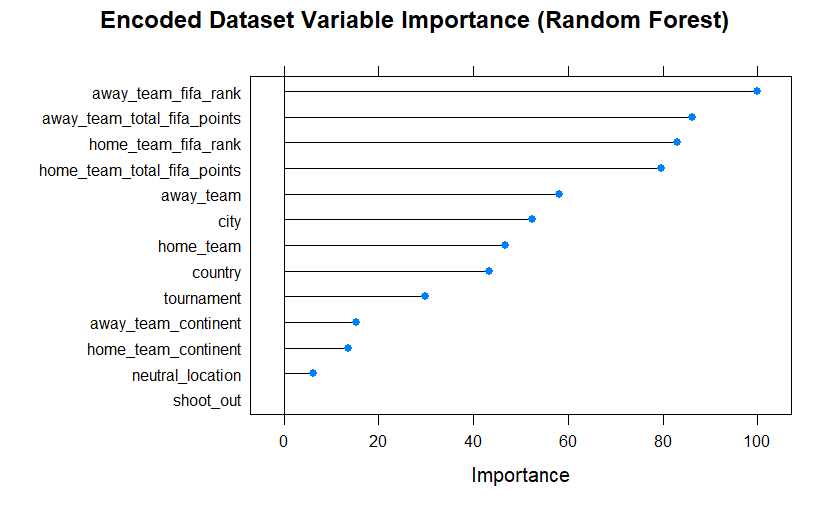

```r
# Repetimos el proceso de Random Forest tras aplicar LabelEncoding
set.seed(355)

## 3-fold CV
supervised_fit_control <- trainControl(
                           method = "repeatedcv",
                           number = 3,
                           repeats = 3)

supervised_random_forest <- train(home_team_result ~., data = supervised_training_set_encoded,
            method = "rf",
            trControl = supervised_fit_control)

supervised_var_importance <- varImp(supervised_random_forest)
plot(supervised_var_importance, main = "Encoded Dataset Variable Importance (Random Forest)")
```

Ahora sí podemos apreciar mejor los resultados del análisis de importancia de las variables. Como esperábamos, las variables que dan información sobre el ranking fifa son las más importantes. El ranking FIFA es el ranking oficial de selecciones, ordenadas de mejor a peor. Tiene sentido que una sección rankeada 1 tenga mayor probabilidad de ganarle a una selección rankeada 100, por eso esperábamos un resultado así.

**Infuencia de la correlación en la selección de atributos**

Sin embargo nos sorprende la importancia de las variables city, country y torneo. Tal y como se estudió al comienzo en el análisis de la correlación, la variable city (que a su vez está correlada con el país y el torneo) influye en el resultado de los partidos cuando estos son amistosos.

Para confirmar los resultados del primer análisis, vamos a estudiar qué relevancia tienen estas variables si solo se tienen en cuenta los partidos amistosos, por lo que repetimos el algoritmo anterior para partidos amistosos:

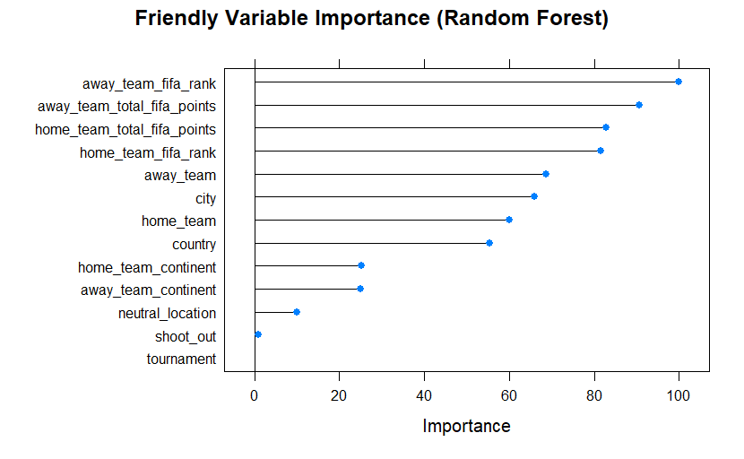

```r
set.seed(355)

supervised_friendly_matches <- supervised_international_matches[supervised_international_matches$tournament == "Friendly",]


supervised_friendly_partition <- createDataPartition(supervised_friendly_matches$home_team_result, p = 0.7, list = FALSE)

supervised_friendly_training_set <- supervised_friendly_matches[supervised_friendly_partition,]
supervised_friendly_test_set <- supervised_friendly_matches[-supervised_friendly_partition,]

supervised_friendly_training_set_encoded <- supervised_friendly_training_set

#Transformamos la columna booleana a 0 y 1
supervised_friendly_training_set_encoded$neutral_location <- as.integer(as.logical(supervised_friendly_training_set_encoded$neutral_location))

# Seleccionar solo las columnas que contienen strings
columns <- names(supervised_friendly_training_set_encoded)[sapply(supervised_friendly_training_set_encoded, is.character)]

# Aplicar una función a cada columna y guardar el resultado en una lista
result <- lapply(supervised_friendly_training_set_encoded[, columns], transform_column_string_to_int)

# Asignar el resultado de vuelta al dataframe
supervised_friendly_training_set_encoded[, columns] <- result

supervised_friendly_partition <- trainControl(
                           method = "repeatedcv",
                           number = 3,
                           repeats = 3)

suppressWarnings(supervised_friendly_random_forest <- train(home_team_result ~.,
            data = supervised_friendly_training_set_encoded,
            method = "rf",
            trControl = supervised_friendly_partition))

supervised_friendly_var_importance <- varImp(supervised_friendly_random_forest)

plot(supervised_friendly_var_importance, main = "Friendly Variable Importance (Random Forest)")
```

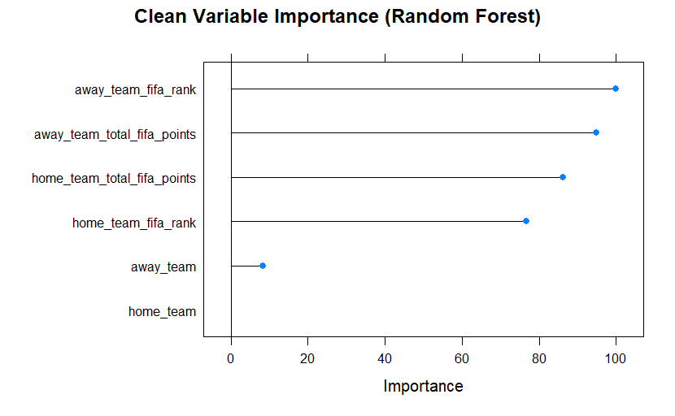

```r
set.seed(355)

supervised_international_matches <- supervised_international_matches[supervised_international_matches$tournament != "Friendly",]

supervised_international_matches <- supervised_international_matches[, -c(3, 4, 9, 10, 11, 12, 13)]


supervised_partition <- createDataPartition(supervised_international_matches$home_team_result, p = 0.7, list = FALSE)

supervised_training_set <- supervised_international_matches[supervised_partition,]
supervised_test_set <- supervised_international_matches[-supervised_partition,]

supervised_training_set_encoded <- supervised_training_set

# Seleccionar solo las columnas que contienen strings
columns <- names(supervised_training_set_encoded)[sapply(supervised_training_set_encoded, is.character)]

# Aplicar una función a cada columna y guardar el resultado en una lista
result <- lapply(supervised_training_set_encoded[, columns], transform_column_string_to_int)

# Asignar el resultado de vuelta al dataframe
supervised_training_set_encoded[, columns] <- result

supervised_fit_control <- trainControl(
                           method = "repeatedcv",
                           number = 3,
                           repeats = 3)

suppressWarnings(supervised_random_forest <- train(home_team_result ~.,
            data = supervised_training_set_encoded,
            method = "rf",
            trControl = supervised_fit_control))

supervised_var_importance <- varImp(supervised_random_forest)
plot(supervised_var_importance, main = "Clean Variable Importance (Random Forest)")
```

**Selección final de atributos**

Podemos ver que ahora sí, las variables que explican el problema son las correspondientes al ranking fifa. Además, la variable shoot_out, que explica si ha habido tanda de penalties no aporta nada de información, no es relevante. Esto significa que los penalties son una lotería, como muchos futbolístas y técnicos afirman. Vamos a mostrar el dataset completo ahora con un summary.

```r
summary(supervised_international_matches)
```

```
  home_team          away_team         home_team_fifa_rank away_team_fifa_rank home_team_total_fifa_points away_team_total_fifa_points
 Length:6174        Length:6174        Min.   :  1.00      Min.   :  1.00      Min.   :   0.0              Min.   :   0.0
 Class :character   Class :character   1st Qu.: 36.00      1st Qu.: 39.00      1st Qu.: 369.0              1st Qu.: 364.0
 Mode  :character   Mode  :character   Median : 78.00      Median : 80.00      Median : 868.0              Median : 857.5
                                       Mean   : 84.91      Mean   : 87.16      Mean   : 839.9              Mean   : 827.2
                                       3rd Qu.:127.00      3rd Qu.:130.00      3rd Qu.:1278.8              3rd Qu.:1261.0
                                       Max.   :211.00      Max.   :211.00      Max.   :2164.0              Max.   :2164.0
 home_team_result
 Length:6174
 Class :character
 Mode  :character
```

**Limpieza del notebook**

Para limpiar el notebook, vamos a eliminar todas las variables del entorno y vamos a cargar los datos preprocesados directamente, del apartado anterior.

```r
rm(list = ls())

international_matches <- read_csv("datasets/international_matches.csv")
colnames <- colnames(international_matches)

# Get data from 2012
supervised_international_matches <- international_matches[as.Date(international_matches$date) >= as.Date("2012-01-01"), ]

# Replace "Draw" and "Lose" for "NoWin"
supervised_international_matches$home_team_result <- gsub("Draw", "Lose", supervised_international_matches$home_team_result)

supervised_international_matches$home_team_result <- gsub("Lose", "NoWin", supervised_international_matches$home_team_result)

# Remove unused columns
supervised_international_matches <- supervised_international_matches[, colnames[1:17]]

supervised_international_matches <- supervised_international_matches[, -c(1, 10, 11)]

# Remove friendly matches
supervised_international_matches <- supervised_international_matches[supervised_international_matches$tournament != "Friendly",]

supervised_international_matches <- supervised_international_matches[, -c(3, 4, 9, 10, 11, 12, 13)]

# Create trainning and test set
supervised_partition <- createDataPartition(supervised_international_matches$home_team_result, p = 0.7, list = FALSE)

supervised_training_set <- supervised_international_matches[supervised_partition,]
supervised_test_set <- supervised_international_matches[-supervised_partition,]

supervised_training_set_encoded <- supervised_training_set
supervised_test_set_encoded <- supervised_test_set


# Seleccionar solo las columnas que contienen strings
columns <- names(supervised_training_set_encoded)[sapply(supervised_training_set_encoded, is.character)]

columns <- head(columns, -1)

transform_column_string_to_int <- function(col){
  col <- as.numeric(factor(col))
}

# Aplicar una función a cada columna y guardar el resultado en una lista
supervised_training_set_encoded[, columns] <- lapply(supervised_training_set_encoded[, columns], transform_column_string_to_int)

supervised_test_set_encoded[, columns] <- lapply(supervised_test_set_encoded[, columns], transform_column_string_to_int)
```

**Entrenamiento de múltiples modelos**

Ahora, con el dataset preprocesado, vamos a empezar a aplicar distintos algoritmos de predicción para obtener el que mejor se comporte. Para ello, vamos a aplicar primero NaiveBayes con los datos sin hacer LabelEncoding, y luego probaremos KNN y SVC con LabelEncoding.

```r
set.seed(355)

supervised_control <- trainControl(
                method = "repeatedcv",
                number = 3,
                classProbs = TRUE,
                savePredictions = "final",
                summaryFunction = twoClassSummary,
                repeats = 3)

# Usar Naive-Bayes con los datos sin LabelEncoding.

supervised_naive_bayes <- train(home_team_result ~., data = supervised_training_set,
            method = "naive_bayes",
            trControl = supervised_control,
            metric="ROC")

# Luego probar con los datos ya codificados con los métodos de KNN y SVC

supervised_knn <- train(home_team_result ~., data = supervised_training_set_encoded,
            method = "knn",
            trControl = supervised_control,
            metric = "ROC",
            tuneGrid = data.frame(k = seq(11,85,by = 2)))


supervised_svm <- train(home_team_result ~., data = supervised_training_set_encoded,
            method = "svmLinear",
            trControl = supervised_control,
            preProcess = c("center","scale"),
            metric = "ROC",
            tuneGrid = expand.grid(C = seq(0.0001, 5, length = 25)))
```

**Evaluación de modelos**

Vamos a comparar esos modelos que hemos obtenido para seleccionar el mejor y poder empezar a predecir el resultado de los partidos.

```r
# Comparación de modelos
resam <- resamples(list(NB  = supervised_naive_bayes,
                        KNN = supervised_knn,
                        SVM = supervised_svm)
                   )
summary(resam)
```

```
Call:
summary.resamples(object = resam)

Models: NB, KNN, SVM
Number of resamples: 9

ROC
         Min.   1st Qu.    Median      Mean   3rd Qu.      Max. NA's
NB  0.7151936 0.7207464 0.7284705 0.7301377 0.7318047 0.7594337    0
KNN 0.7409395 0.7467121 0.7594192 0.7627489 0.7807192 0.7911499    0
SVM 0.7458626 0.7628643 0.7692742 0.7660134 0.7706482 0.7785845    0

Sens
         Min.   1st Qu.    Median      Mean   3rd Qu.      Max. NA's
NB  0.0000000 0.8750000 1.0000000 0.7859916 1.0000000 1.0000000    0
KNN 0.6787634 0.6841398 0.6948925 0.6942951 0.7029570 0.7069892    0
SVM 0.6881720 0.7096774 0.7177419 0.7174432 0.7284946 0.7432796    0

Spec
         Min.   1st Qu.    Median      Mean   3rd Qu.      Max. NA's
NB  0.0000000 0.0000000 0.0000000 0.2541049 0.3314204 1.0000000    0
KNN 0.6341463 0.6743185 0.7159254 0.7017376 0.7216643 0.7388809    0
SVM 0.6413199 0.6671449 0.6700143 0.6698549 0.6757532 0.6958393    0
```

**Selección del mejor clasificador**

Esta es una de las partes cruciales del proyecto. Para determinar qué modelo es el mejor, tendremos que tener en cuenta las métricas de rendimiento más importantes para nuestra aplicación concreta, la predicción de partidos.

No hay un modelo mejor, sino que para cada caso, elegiremos uno guiándonos por las métricas de evaluación. Tenemos las siguientes métricas:

1. La sensibilidad de un modelo de clasificación es la fracción de instancias positivas que son correctamente identificadas por el modelo. Es decir, la sensibilidad mide cuán bueno es el modelo para detectar las instancias positivas
2. La especificidad es la fracción de instancias negativas que son correctamente identificadas por un modelo de clasificación. Es decir, mide cuán bueno es el modelo para detectar las instancias negativas.
3. La AUC (Área bajo la Curva) o AUROC (Área bajo la Curva ROC) es una medida de rendimiento comúnmente utilizada en el análisis de clasificación binaria. La curva ROC es un gráfico que muestra la tasa de verdaderos positivos (sensibilidad) en el eje Y en función de la tasa de falsos positivos (1 - especificidad) en el eje X, para diferentes umbrales de clasificación.

Por ejemplo, si somos corredores de apuestas, nos interesa saber con la mayor exactitud, en qué medida un equipo ganará seguro o perderá seguro, para realizar apuestas seguras, usando la sensibilidad (gana seguro) o especificidad (pierde seguro). Sin embargo, como queremos realizar una predicción imparcial y neutra, vamos a utilizar la AUROC, ya que está basada en las métricas anteriores de manera equitativa.

```r
# Nos quedamos con el modelo con mejor media de AUROC.
final_model <- supervised_svm
```

**Predicción de los resultados del mundial de Qatar 2022**

Con el mejor modelo ya seleccionado, ahora vamos a realizar la parte final del ejercicio supervisado, la predicción de partidos del mundial. Para ello, cargamos el dataset “results”, que contiene los resultados de todos los partidos jugados en el mundial. Algo importante a notar, es que este dataset debe tener la misma estructura que el dataset con el que entrenamos al modelo. Sin embargo, no había ningún dataset con la misma estructura en Internet, por ello hemos montado un script (en python) que nos ha parseado todo el mundial de la manera adecuada para el algoritmo. (/scripts/parser.py)

```r
worldcup_2022_matches <- read_csv("datasets/results.csv")
worldcup_2022_matches
```

| home_team | away_team | home_team_fifa_rank | away_team_fifa_rank | home_team_total_fifa_points | away_team_total_fifa_points | home_team_result | group |
| --- | --- | --- | --- | --- | --- | --- | --- |
| Qatar | Ecuador | 101 | 60 | 332 | 1376 | Lose | Group A |
| England | IR Iran | 16 | 33 | 1046 | 791 | Win | Group B |
| Senegal | Netherlands | 27 | 21 | 861 | 963 | Lose | Group A |
| USA | Wales | 25 | 20 | 867 | 983 | Draw | Group B |
| Argentina | Saudi Arabia | 5 | 64 | 1253 | 521 | Lose | Group C |
| Denmark | Tunisia | 12 | 23 | 1098 | 919 | Draw | Group D |
| Mexico | Poland | 17 | 6 | 1032 | 1228 | Draw | Group C |
| France | Australia | 9 | 37 | 1185 | 740 | Win | Group D |
| Morocco | Croatia | 40 | 18 | 737 | 975 | Draw | Group F |
| Germany | Japan | 1 | 55 | 1609 | 593 | Lose | Group E |

[output cut: 54 more lines]

Como el csv de entrada debe mantener el formato del csv usado para entrenar, también debemos aplicar LabelEncoding a este dataset. Sino, no será capaz de aprender y encontrar las relaciones para predecir.

```r
# Funcion de mapeo a label encoding
labelMapper <- function(columna_valores, columna_codificacion) {
  for(valor in columna_valores) {
    indice <- which(columna_valores == valor)
    if (length(indice) > 0) {
      columna_valores[indice] <- columna_codificacion[indice]  }
  }
  return (as.numeric(factor(columna_valores)))
}

# Aplicacion de label encoding a las columnas home_team y away_team
worldcup_2022_matches_encoded <- worldcup_2022_matches

worldcup_2022_matches_encoded$home_team <- labelMapper(worldcup_2022_matches$home_team, supervised_training_set_encoded$home_team)

worldcup_2022_matches_encoded$away_team <- labelMapper(worldcup_2022_matches$away_team, supervised_training_set_encoded$away_team)

worldcup_2022_matches_encoded
```

| home_team | away_team | home_team_fifa_rank | away_team_fifa_rank | home_team_total_fifa_points | away_team_total_fifa_points | home_team_result | group |
| --- | --- | --- | --- | --- | --- | --- | --- |
| 14 | 3 | 101 | 60 | 332 | 1376 | Lose | Group A |
| 22 | 14 | 16 | 33 | 1046 | 791 | Win | Group B |
| 35 | 24 | 27 | 21 | 861 | 963 | Lose | Group A |
| 4 | 20 | 25 | 20 | 867 | 983 | Draw | Group B |
| 40 | 13 | 5 | 64 | 1253 | 521 | Lose | Group C |
| 9 | 28 | 12 | 23 | 1098 | 919 | Draw | Group D |
| 35 | 38 | 17 | 6 | 1032 | 1228 | Draw | Group C |
| 11 | 28 | 9 | 37 | 1185 | 740 | Win | Group D |
| 29 | 45 | 40 | 18 | 737 | 975 | Draw | Group F |
| 42 | 7 | 1 | 55 | 1609 | 593 | Lose | Group E |

[output cut: 54 more lines]

Ahora, vamos a predecir finalmente todos los partidos. Nuestro algoritmo predice las probabilidades de ganar o no ganar del equipo local.

**Fase de grupos**: Si las probabilidades de ganar superan un umbral del 0.65, podemos el algoritmo dirá que el equipo local va a ganar el partido. Si las probabilidades de no ganar son del 0.65, el algoritmo dirá que el equipo local perderá. En caso contrario, si ninguna de las dos probabilidades son lo suficientemente fuertes, el algoritmo dirá que el partido quedará en empate.

**Eliminatorias**: En este caso, no se puede empatar. Si los dos equipos empatan, van a la prórroga, y si empatan en la prórroga irán a penalties. Debe haber un vencedor y un vencido obligatoriamente. Por ello, si las probabilidades de ganar superan un umbral del 0.5, podemos el algoritmo dirá que el equipo local va a ganar el partido. Si las probabilidades de no ganar son del 0.5, el algoritmo dirá que el equipo local perderá.

```r
# Division en fase de grupos y clasificatoria
knockout <- worldcup_2022_matches_encoded[str_detect(worldcup_2022_matches_encoded$group, regex("Group [A-H]")),1:7]

classif <- worldcup_2022_matches_encoded[!str_detect(worldcup_2022_matches_encoded$group, regex("Group [A-H]")),1:7]

# Hace predicciones sobre el conjunto de prueba
probsClassif <- predict(final_model,classif, type="prob")
probsKnockout <-predict(final_model,knockout, type="prob")

# Transforma las probabilidades a etiquetas "Win" "Lose" y "Draw" en fase de grupos y "Win" y "Lose" si es un partido clasificatorio
probsClassif <- factor(ifelse(probsClassif$Win > 0.5, "Win", "Lose"))
probsKnockout <- factor(
  ifelse(probsKnockout$Win > 0.65, "Win",
  ifelse(probsKnockout$NoWin > 0.65, "Lose", "Draw" )))

probs <- c(probsKnockout, probsClassif)

# Crea un nuevo dataset con los resultados para su visualizacion
resultds <- worldcup_2022_matches[, -c(-1,-2,-8)]
resultds$home_team_result_pred <- probs
resultds
```

| home_team | away_team | group | home_team_result_pred |
| --- | --- | --- | --- |
| Qatar | Ecuador | Group A | Lose |
| England | IR Iran | Group B | Draw |
| Senegal | Netherlands | Group A | Draw |
| USA | Wales | Group B | Draw |
| Argentina | Saudi Arabia | Group C | Win |
| Denmark | Tunisia | Group D | Draw |
| Mexico | Poland | Group C | Draw |
| France | Australia | Group D | Draw |
| Morocco | Croatia | Group F | Lose |
| Germany | Japan | Group E | Win |

[output cut: 54 more lines]

Finalmente, tenemos la predicción de los partidos. Ahora podemos compararlos con los resultados reales que se han dado, y podemos obtener las métricas de acierto y fallo usando la matriz de confusión

```r
true_labels <- as.factor(worldcup_2022_matches$home_team_result)

# Calcula la matriz de confusión
confusion_matrix <- confusionMatrix(probs, true_labels, mode="everything")
confusion_matrix
```

```
Confusion Matrix and Statistics

          Reference
Prediction Draw Lose Win
      Draw    6    8   8
      Lose    3   10  13
      Win     1    3  12

Overall Statistics

               Accuracy : 0.4375
                 95% CI : (0.3137, 0.5672)
    No Information Rate : 0.5156
    P-Value [Acc > NIR] : 0.91560

                  Kappa : 0.1777

 Mcnemar's Test P-Value : 0.00295

Statistics by Class:

                     Class: Draw Class: Lose Class: Win
Sensitivity              0.60000      0.4762     0.3636
Specificity              0.70370      0.6279     0.8710
Pos Pred Value           0.27273      0.3846     0.7500
Neg Pred Value           0.90476      0.7105     0.5625
Precision                0.27273      0.3846     0.7500
Recall                   0.60000      0.4762     0.3636
F1                       0.37500      0.4255     0.4898
Prevalence               0.15625      0.3281     0.5156
Detection Rate           0.09375      0.1562     0.1875
Detection Prevalence     0.34375      0.4062     0.2500
Balanced Accuracy        0.65185      0.5520     0.6173
```

Podemos ver que el ACC se encuentra en torno al 45%, lo que significa que nuestro modelo no predice con mucha precisión los resultados. Esto se debe a que en este mundial, se han obtenido resultados realmente extraños, como Arabia Saudí venciendo a la campeona Argentina, Marruecos llegando a las semifinales del mundial (primera vez en toda la historia de fútbol que una selección africana llega a semifinales), España siendo eliminadas en octavos y la favorita Brasil siendo eliminada en cuartos.

## Aprendizaje No Supervisado: Clasificación de equipos según sus métricas

Vamos a diseñar un algoritmo de aprendizaje no supervisado para la segunda parte del proyecto. Nuestra idea es, en base a las columnas de puntuación del dataset original, clusterizar los equipos en base a sus puntuaciones en portería, defensa, mediocentro y ataque y ver qué conclusiones podemos obtener. Usaremos un algoritmo de tipo kmedias usando la información del csv original.

**Preprocesamiento**

Cabe destacar, que en este caso, hemos realizado unas modificaciones al set en Python, con los scripts `/scripts/cleaner.py` y `/scripts/scorer.py`. Como resumen del funcionamiento de estos scripts, toman el dataset original “international_matches”, eliminamos los amistosos para deshacernos de la correlación de cuidad-torneo-pais y calculamos la media de puntos en portería, defensa, medio y ataque para cada país. Esta información la volcamos en el dataset “kmedias_input”.

```r
teams_data <- read_csv("datasets/kmedias_input.csv")
teams_data_reversed <- as.data.frame(apply(teams_data, 2, rev))
teams_data_reversed
```

| team | fifa_rank | total_fifa_points | goalkeeper_score | mean_defense_score | mean_offense_score | mean_midfield_score |
| --- | --- | --- | --- | --- | --- | --- |
| Qatar | 46 | 1437 | NA | NA | NA | NA |
| IR Iran | 21 | 1572 | 68.36066 | 68.97241 | 70.98276 | 69.99512 |
| Saudi Arabia | 53 | 1433 | 70.91803 | 71.33607 | 70.51967 | 73.08525 |
| Japan | 23 | 1549 | 70.38150 | 72.69239 | 72.84113 | 76.91157 |
| Senegal | 18 | 1587 | 72.35829 | 77.51444 | 79.81818 | 76.35027 |
| Korea Republic | 29 | 1522 | 73.84825 | 72.64669 | 75.08949 | 75.06031 |
| Australia | 37 | 1486 | 78.35961 | 72.60345 | 74.43054 | 74.16798 |
| Argentina | 4 | 1765 | 80.69397 | 82.98190 | 88.26034 | 84.42802 |
| Morocco | 24 | 1551 | 72.08673 | 75.72857 | 77.05612 | 76.47194 |
| Costa Rica | 31 | 1503 | 78.62439 | 69.99879 | 71.24525 | 70.52016 |

[output cut: 22 more lines]

**Imputación de valores**

Sin embargo, tenemos valores faltantes dentro del dataset, como se puede ver en el caso de Qatar (se ha mostrado el dataset invertido para evidenciar esto). Para ello, usaremos la imputación de valores faltantes a través de la función preProcess de Caret con el método medianImpute.

```r
# Interpolar valores nulos del dataset
qatar = teams_data[nrow(teams_data), ]
bagMissing <- preProcess(teams_data, method = "medianImpute")
teams_data[nrow(teams_data), ] <- predict(bagMissing, qatar)
rownames(teams_data) <- teams_data$team
teams_data_reversed <- as.data.frame(apply(teams_data, 2, rev))[-c(1)]
teams_data_reversed
```

|  | fifa_rank | total_fifa_points | goalkeeper_score | mean_defense_score | mean_offense_score | mean_midfield_score |
| --- | --- | --- | --- | --- | --- | --- |
| Qatar | 46 | 1437 | 78.67633 | 77.51444 | 78.25787 | 78.35266 |
| IR Iran | 21 | 1572 | 68.36066 | 68.97241 | 70.98276 | 69.99512 |
| Saudi Arabia | 53 | 1433 | 70.91803 | 71.33607 | 70.51967 | 73.08525 |
| Japan | 23 | 1549 | 70.38150 | 72.69239 | 72.84113 | 76.91157 |
| Senegal | 18 | 1587 | 72.35829 | 77.51444 | 79.81818 | 76.35027 |
| Korea Republic | 29 | 1522 | 73.84825 | 72.64669 | 75.08949 | 75.06031 |
| Australia | 37 | 1486 | 78.35961 | 72.60345 | 74.43054 | 74.16798 |
| Argentina | 4 | 1765 | 80.69397 | 82.98190 | 88.26034 | 84.42802 |
| Morocco | 24 | 1551 | 72.08673 | 75.72857 | 77.05612 | 76.47194 |
| Costa Rica | 31 | 1503 | 78.62439 | 69.99879 | 71.24525 | 70.52016 |

[output cut: 22 more lines]

Con medianImpute hemos obtenido unos valores que se ajustan a la realidad, ya que Qatar esta rankeada con valoraciones similares a equipos que sabemos que tienen el mismo nivel, como Ecuador o Ghana.

**Entrenamiento de múltiples modelos no supervisados - Clustering**

Ahora que ya tenemos todos los valores, vamos a entrenar distintos modelos de clustering para agrupar los equipos en función de sus puntuaciones de ataque, defensa, centro del campo y portería.

```r
# Normaliza las columnas que quieres usar para agrupar los equipos
teams_data_normalized <- scale(teams_data[, colnames(teams_data)[-1]])

# k-medias con k = 3 clústeres y 10 iteraciones
kmeans_clustering <- kmeans(teams_data_normalized, 3, nstart = 10)

# C-medias con k=3 clústeres utilizando distancia euclídea
Cmeans_euclidean_clustering <- fanny(teams_data, diss=FALSE, k=3,
                                 metric="euclidean", stand=FALSE)

# C-medias con k=3 clústeres utilizando distancia manhattan
Cmeans_sqeuclidean_clustering <- fanny(teams_data, diss=FALSE, k=3,
                                 metric="SqEuclidean", stand=FALSE)
```

Hemos obtenido 3 clusteres de equipos en cada uno de los modelos. Ahora vamos a evaluar los modelos obtenidos contra el ranking FIFA para seleccionar el mejor.

**Evaluación de los modelos**

En primer lugar, vamos a crear una agrupación de referencia basandonos en el ranking FIFA:

```r
team_cluster <- teams_data$team
team_ranking_ordered <- teams_data$team[order(teams_data$fifa_rank)]

mejores <- team_ranking_ordered[1:10]
medianos <- team_ranking_ordered[11:21]
peores <- team_ranking_ordered[22:32]

for (i in 1:length(team_cluster)) {
  if (team_cluster[i] %in% mejores) {
    team_cluster[i] <- 1
  } else if (team_cluster[i] %in% medianos) {
    team_cluster[i] <- 2
  } else {
    team_cluster[i] <- 3
  }
}

team_cluster <- as.data.frame(team_cluster)
team_cluster$team <- teams_data$team
team_cluster
```

| team_cluster | team |
| --- | --- |
| 3 | Tunisia |
| 3 | Ghana |
| 1 | Belgium |
| 2 | Wales |
| 2 | USA |
| 1 | Mexico |
| 2 | Croatia |
| 3 | Canada |
| 2 | Serbia |
| 1 | Portugal |

[output cut: 22 more lines]

Utilizaremos las métricas ARI (Adjusted Rand Index) y AMI (Adjusted Mutual Information), que determinan la disimilaridad del clustering con respecto a otro clustering, además de la silueta, medida que combina la distancia intraclúster e interclúster en su cálculo.

- **ARI**: El índice ajustado de Rand (ARI) es una medida de la similitud entre dos agrupamientos que considera todos los pares de muestras y cuenta el número de ellas que están asignadas al mismo grupo en ambos agrupamientos. Tiene un rango de -1 a 1, siendo un valor de 1 indicativo de que los dos agrupamientos son exactamente iguales y un valor de -1 indicativo de que son exactamente opuestos. El ARI no es sensible al número de grupos, pero puede ser sensible al tamaño de los grupos.
- **AMI**: La información mutua ajustada (AMI) es una medida de la similitud entre dos agrupamientos que se basa en la información mutua entre ellos. Tiene un rango de -1 a 1, siendo un valor de 1 indicativo de que los dos agrupamientos son exactamente iguales y un valor de -1 indicativo de que son exactamente opuestos. La AMI es más robusta que el ARI, pero puede ser sensible al número de grupos y puede no ser adecuada para conjuntos de datos muy pequeños.
- **Silhouette:** La silueta es una medida que calcula la “cohesión” y la “separación” de una muestra dentro de un grupo y entre grupos. Tiene un rango de -1 a 1, siendo un valor de 1 indicativo de que la muestra está bien separada de otros grupos y un valor de -1 indicativo de que la muestra está cerca del límite entre dos grupos. La silueta no es sensible al número de grupos, pero puede no ser fiable cuando los grupos tienen tamaños o densidades muy diferentes.

Como medida de confianza para el cálculo del ARI y del AMI, utilizaremos el ranking FIFA real a modo de referencia para evaluar la agrupación obtenida por cada uno de nuestros modelos.

```r
rank <- team_cluster$team_cluster

# Compute the ARI between the kmeans and FCM clusters
kmeans_ari <- ARI(kmeans_clustering$cluster, rank)
cmeans_e_ari <- ARI(Cmeans_euclidean_clustering$cluster, rank)
cmeans_sq_ari <- ARI(Cmeans_sqeuclidean_clustering$cluster, rank)

# Compute the AMI between the kmeans and FCM clusters
kmeans_ami <- AMI(kmeans_clustering$cluster, rank)
cmeans_e_ami <- AMI(Cmeans_euclidean_clustering$cluster, rank)
cmeans_sq_ami <- AMI(Cmeans_sqeuclidean_clustering$cluster, rank)

# Compute the Silhouette for every model
suppressWarnings({
  kmeans_silhouette <- mean(as.data.frame(
            silhouette(kmeans_clustering$cluster, dist(team_cluster)))$sil_width)
  cmeans_e_silhouette <- mean(as.data.frame(
            silhouette(Cmeans_euclidean_clustering))$sil_width)
  cmeans_sq_silhouette <- mean(as.data.frame(
            silhouette(Cmeans_sqeuclidean_clustering))$sil_width)
})

cat("Comparativa de ARIs")
```

```
Comparativa de ARIs
```

```r
cat(paste("\nKmeans ARI =", kmeans_ari))
```

```
Kmeans ARI = 0.366336633663366
```

```r
cat(paste("\nCmeans ARI con distancia euclidea =", cmeans_e_ari))
```

```
Cmeans ARI con distancia euclidea = 0.485193621867882
```

```r
cat(paste("\nCmeans ARI con distancia euclidea cuadrática =", cmeans_sq_ari))
```

```
Cmeans ARI con distancia euclidea cuadrática = 0.450759707371975
```

```r
cat("\n\nComparativa de AMIs")
```

```
Comparativa de AMIs
```

```r
cat(paste("\nKmeans AMI =", kmeans_ami))
```

```
Kmeans AMI = 0.386837891325094
```

```r
cat(paste("\nCmeans AMI con distancia euclidea =", cmeans_e_ami))
```

```
Cmeans AMI con distancia euclidea = 0.545896378875695
```

```r
cat(paste("\nCmeans AMI con distancia euclidea cuadrática =", cmeans_sq_ami))
```

```
Cmeans AMI con distancia euclidea cuadrática = 0.51420268909183
```

```r
cat("\n\nComparativa de Silhouette")
```

```
Comparativa de Silhouette
```

```r
cat(paste("\nKmeans Silhouette mean =", kmeans_silhouette))
```

```
Kmeans Silhouette mean = 0.344353505291005
```

```r
cat(paste("\nCmeans Silhouette mean con distancia euclidea =", cmeans_e_silhouette))
```

```
Cmeans Silhouette mean con distancia euclidea = 0.561040592165388
```

```r
cat(paste("\nCmeans Silhouette mean  con distancia euclidea cuadrática =", cmeans_sq_silhouette))
```

```
Cmeans Silhouette mean  con distancia euclidea cuadrática = 0.750412203967254
```

**Selección del mejor modelo**

A la vista de los resultados arrojados por el cálculo de las métricas anteriores, y teniendo en cuenta que estamos ante un conjunto de datos de tamaño reducido, es más apropiado utilizar la silueta para decidir cuál de los modelos es mejor. Así, a pesar de ser el modelo Cmeans con distancia euclídea aquel que obtiene más puntuación en ARI y AMI, el modelo óptimo para este caso sería Cmeans con distancia euclídea cuadrática, ya que arroja resultados significativamente superiores en la silueta, lo cual es indicativo de que los grupos hallados tienen una alta cohesión y separación.

```r
unsupervised_final_model <- Cmeans_sqeuclidean_clustering
```

**Visualización de los clústeres del modelo seleccionado**

La siguiente función auxiliar muestra las gráficas de ataque, defensa, medio campo y portería obtenidas a partir del algoritmo de clustering cuyo resultado se especifique en el primer argumento.

```r
show_team_stats_plot <- function(cluster_df, cluster_col) {
  teams_data_copy <- teams_data

  result <- cluster_df[[cluster_col]]

  clusters <- vector("list", length = length(unique(result)))
  colormap <- colorRampPalette(c("red", "yellow", "green"))(length(unique(result)))

  teams_data_copy$color <- "#000000"

  for (val in unique(result)) {
    cluster <- which(result == val)
    clusters[[val]] <- c(teams_data_copy[cluster,])
    for (team in clusters[[val]]$team) {
      teams_data_copy[teams_data_copy$team == team, ]$color <- colormap[[val]]
    }
  }

  plot1 <- ggplot(teams_data_copy, aes(x = fifa_rank, y = goalkeeper_score, color = color)) + geom_point(show.legend = FALSE) + geom_text_repel(aes(label = team), show.legend = FALSE) + ggtitle("Goalkeeper Score")

  plot2 <- ggplot(teams_data_copy, aes(x = fifa_rank, y = mean_defense_score, color = color )) + geom_point(show.legend = FALSE) + geom_text_repel(aes(label = team), show.legend = FALSE) + ggtitle("Mean Defense Score")

  plot3<- ggplot(teams_data_copy, aes(x = fifa_rank, y = mean_offense_score, color = color)) + geom_point(show.legend = FALSE) + geom_text_repel(aes(label = team), show.legend = FALSE) + ggtitle("Mean Offense Score")

  plot4 <- ggplot(teams_data_copy, aes(x = fifa_rank, y = mean_midfield_score, color = color)) + geom_point(show.legend = FALSE) + geom_text_repel(aes(label = team), show.legend = FALSE) + ggtitle("Mean Midfield Score")

  suppressWarnings(gridExtra::grid.arrange(plot1, plot2, plot3, plot4))
}
```

A continuación, se presenta el agrupamiento realizado por el modelo de Cmeans con distancia euclídea cuadrática:

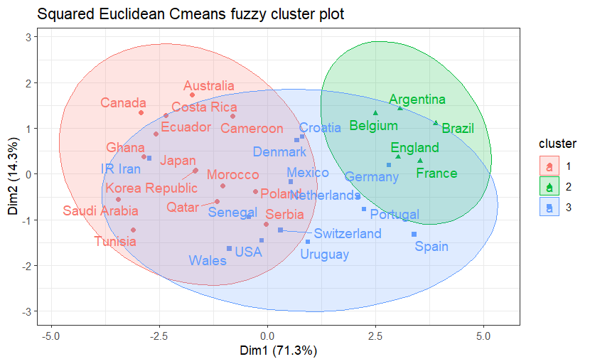

```r
# Cmeans euclidean cluster visualization
fviz_cluster(unsupervised_final_model, repel=TRUE, ellipse.type = "norm", pallete="jco") + theme_bw() + labs(title = "Squared Euclidean Cmeans fuzzy cluster plot")
```

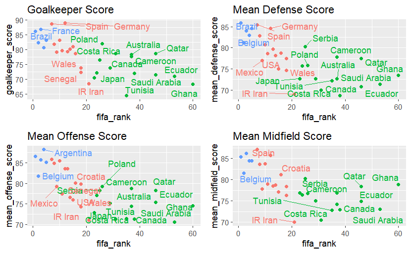

```r
show_team_stats_plot(unsupervised_final_model, "clustering")
```

Los 3 clústeres tienen sentido ya que podemos encontrar relaciones entre los miembros de cada cluster.

Podemos ver que en los 4 casos planteados, (portería, defensa, mediocentro, ataque), tenemos los mismos clusteres con los mismos equipos. La distribución es muy parecida, aunque no siempre igual. Por ejemplo, España destaca en el centro del campo pero carece en ofensiva, al contrario que Brasil y Argentinca, que denotan un mejor ataque que defensa. De nuevo, tiene sentido ya que estas selecciones son conocidas por la gran cantidad de atacantes élite que ha mantenido.

## Conclusiones del proyecto

En este proyecto hemos desarrollado dos tipos de algoritmos. Un algoritmo de aprendizaje supervisado para la predicción del resultado de los partidos del mundial de Qatar 2022, y un algoritmo de aprendizaje no supervisado para la clusterización y clasificación de estos equipos participantes del mundial en base a 4 parámetros de portería, defensa, mediocentro y ataque.

Hemos realizado distintas tareas, junto con todas sus explicaciones:

Es crucial trabajar bien el dataset y estructurar los datos de manera adecuada antes de pasar a implementar algoritmos de aprendizaje. Puede no existir un "mejor" modelo. Dependiendo de en qué casos, puede interesarnos más un clasificador que otro, incluso cuando en la evaluación haya obtenido peor puntuación.

Hemos podido conocer más a fondo el mundo del científico e ingeniero de datos, los procesos y tareas de un proyecto de inteligencia artificial y big data, aprender más sobre R y su utilidad para este sector y obtener varias conclusiones interesantes al respecto.